# chap3_bar_graphs

### 3.4 Using colors in a bar graph

아래 예제로 사용할 `uspopchange`data는 2000년에서 2010년까지의 미국 주별 인구 변화율을 나타낸 데이터이다.  
그래프를 그려 인구 변화율이 가장 큰 10개 주를 찾도록 해보자.  
또한 지역별로 다른 색의 bar를 그려본다.  
우선 top10을 찾는다.

```r
uspopchange
```

```
##             State Abb        Region Change
## 1         Alabama  AL         South    7.5
## 2          Alaska  AK          West   13.3
## 3         Arizona  AZ          West   24.6
## 4        Arkansas  AR         South    9.1
## 5      California  CA          West   10.0
## 6        Colorado  CO          West   16.9
## 7     Connecticut  CT     Northeast    4.9
## 8        Delaware  DE         South   14.6
## 10        Florida  FL         South   17.6
## 11        Georgia  GA         South   18.3
## 12         Hawaii  HI          West   12.3
## 13          Idaho  ID          West   21.1
## 14       Illinois  IL North Central    3.3
## 15        Indiana  IN North Central    6.6
```

[output cut: 36 more lines]

```r
upc <- uspopchange %>% subset(rank(Change) > 40)

upc
```

```
##             State Abb Region Change
## 3         Arizona  AZ   West   24.6
## 6        Colorado  CO   West   16.9
## 10        Florida  FL  South   17.6
## 11        Georgia  GA  South   18.3
## 13          Idaho  ID   West   21.1
## 29         Nevada  NV   West   35.1
## 34 North Carolina  NC  South   18.5
## 41 South Carolina  SC  South   15.3
## 44          Texas  TX  South   20.6
## 45           Utah  UT   West   23.8
```

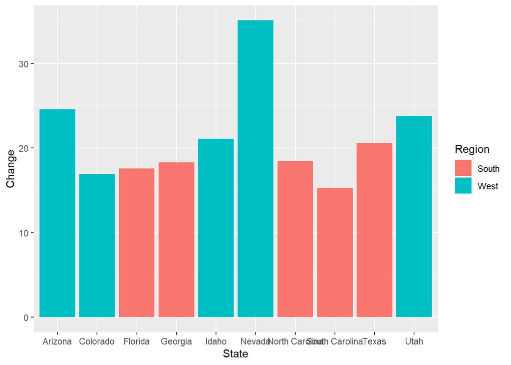

```r
ggplot(upc, aes(x = State, y = Change, fill = Region)) +
  geom_bar(stat = "identity")
```

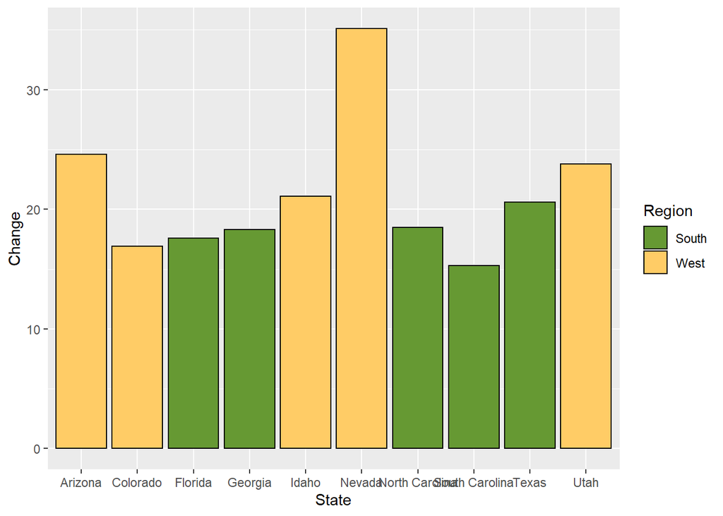

```r
ggplot(upc, aes(x = State, y = Change, fill = Region)) +
  geom_bar(stat = "identity", color = "#000000") +
  scale_fill_manual(values = c("#669933", "#FFCC66")) +
  labs(x = "State")
```

### 3.5 Coloring negative and positive bars differently

`climate`data에서 1900년이후 Berkeley의 데이터만 추출하여 값이 양수인지 음수인지 판단한 **pos**라는 새로운 열을 만든다.

```r
climate
```

```
##       Source Year    Anomaly1y    Anomaly5y   Anomaly10y Unc10y
## 1   Berkeley 1800           NA           NA -0.435000000  0.505
## 2   Berkeley 1801           NA           NA -0.453000000  0.493
## 3   Berkeley 1802           NA           NA -0.460000000  0.486
## 4   Berkeley 1803           NA           NA -0.493000000  0.489
## 5   Berkeley 1804           NA           NA -0.536000000  0.483
## 6   Berkeley 1805           NA           NA -0.541000000  0.475
## 7   Berkeley 1806           NA           NA -0.590000000  0.468
## 8   Berkeley 1807           NA           NA -0.695000000  0.461
## 9   Berkeley 1808           NA           NA -0.763000000  0.453
## 10  Berkeley 1809           NA           NA -0.818000000  0.451
## 11  Berkeley 1810           NA           NA -0.842000000  0.437
## 12  Berkeley 1811           NA           NA -0.912000000  0.406
## 13  Berkeley 1812           NA           NA -0.963000000  0.395
## 14  Berkeley 1813           NA           NA -1.015000000  0.389
```

[output cut: 485 more lines]

```r
csub <-
  climate %>%
  subset(Source == "Berkeley" & Year >= 1900) %>%
  mutate(pos = as.logical(Anomaly10y >= 0))

csub
```

```
##       Source Year Anomaly1y Anomaly5y Anomaly10y Unc10y   pos
## 101 Berkeley 1900        NA        NA     -0.171  0.108 FALSE
## 102 Berkeley 1901        NA        NA     -0.162  0.109 FALSE
## 103 Berkeley 1902        NA        NA     -0.177  0.108 FALSE
## 104 Berkeley 1903        NA        NA     -0.199  0.104 FALSE
## 105 Berkeley 1904        NA        NA     -0.223  0.105 FALSE
## 106 Berkeley 1905        NA        NA     -0.241  0.107 FALSE
## 107 Berkeley 1906        NA        NA     -0.294  0.106 FALSE
## 108 Berkeley 1907        NA        NA     -0.312  0.105 FALSE
## 109 Berkeley 1908        NA        NA     -0.328  0.103 FALSE
## 110 Berkeley 1909        NA        NA     -0.281  0.101 FALSE
## 111 Berkeley 1910        NA        NA     -0.247  0.099 FALSE
## 112 Berkeley 1911        NA        NA     -0.243  0.097 FALSE
## 113 Berkeley 1912        NA        NA     -0.257  0.100 FALSE
## 114 Berkeley 1913        NA        NA     -0.268  0.100 FALSE
```

[output cut: 91 more lines]

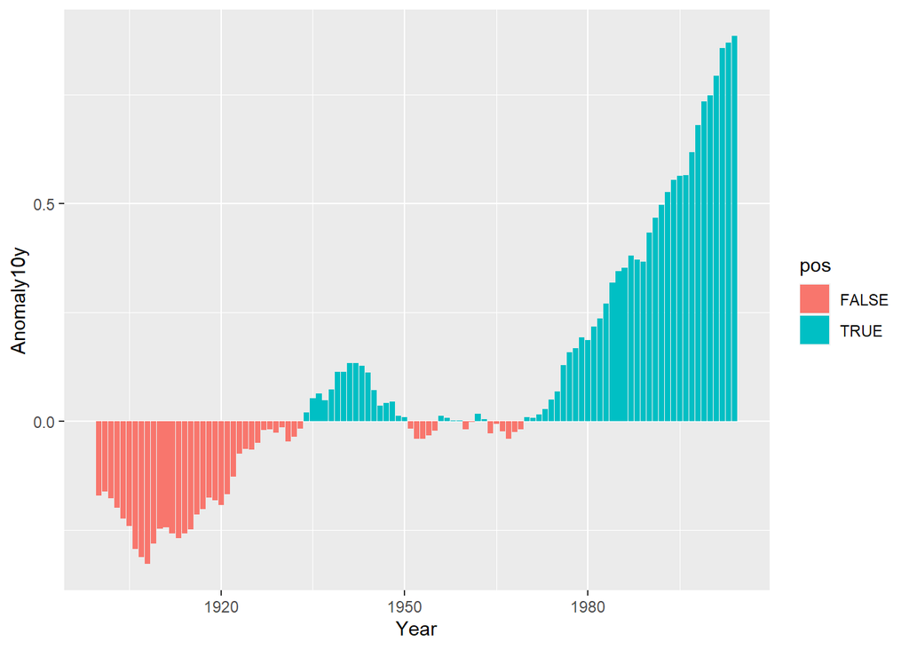

```r
csub %>%
  ggplot(aes(x = Year, y = Anomaly10y, fill = pos)) +
  geom_bar(stat = "identity")
```

위와 같은 bar graph는 두 가지 문제가 있다.  
첫번째는 일반적으로 양수를 빨간색, 음수를 파란색으로 표현하는데 반대로 색이 칠해져있고, 두번째는 범례가 필요없어 보인다.  
문제점을 없애기 위해서 `scale_fill_manual()`로 색을 지정해주고, 범례를 없애준다.

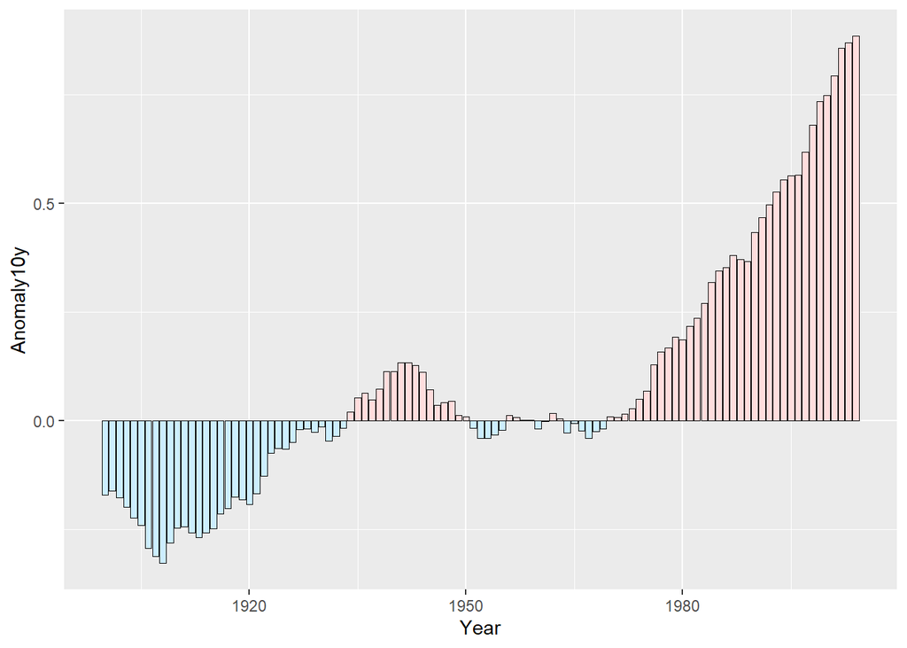

```r
csub %>%
  ggplot(aes(x = Year, y = Anomaly10y, fill = pos)) +
  geom_bar(stat = "identity", color = "#000000", size = 0.25) +
  scale_fill_manual(values = c("#CCEEFF","#FFDDDD")) +
  theme(legend.position = "none")
```

### 3.6 Adjusting bar width and spacing

bar의 넓이를 조절하고 싶으면 `geom_bar()`에서 `width`값으로 가능하다.  
기본값은 0.9로 되어 있다.

```r
pg_mean
```

```
##   group weight
## 1  ctrl  5.032
## 2  trt1  4.661
## 3  trt2  5.526
```

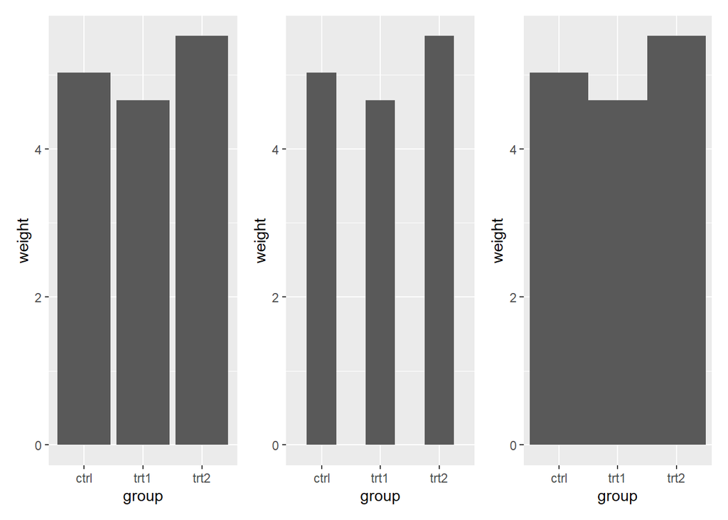

```r
pg1 <-
  pg_mean %>%
  ggplot(aes(x = group, y = weight)) +
  geom_bar(stat = "identity")

pg2 <-
  pg_mean %>%
  ggplot(aes(x = group, y = weight)) +
  geom_bar(stat = "identity", width = 0.5)

pg3 <-
  pg_mean %>%
  ggplot(aes(x = group, y = weight)) +
  geom_bar(stat = "identity", width = 1.0)

pg1 + pg2 + pg3
```

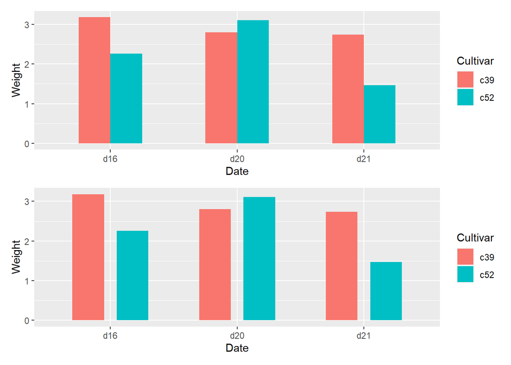

```r
cab1 <-
  cabbage_exp %>%
  ggplot(aes(x = Date, y = Weight, fill = Cultivar)) +
  geom_bar(stat = "identity", width = 0.5, position = "dodge")

cab2 <-
  cabbage_exp %>%
  ggplot(aes(x = Date, y = Weight, fill = Cultivar)) +
  geom_bar(stat = "identity", width = 0.5, position = position_dodge(0.7))

cab1 / cab2
```

### 3.7 Making a stacked bar graph

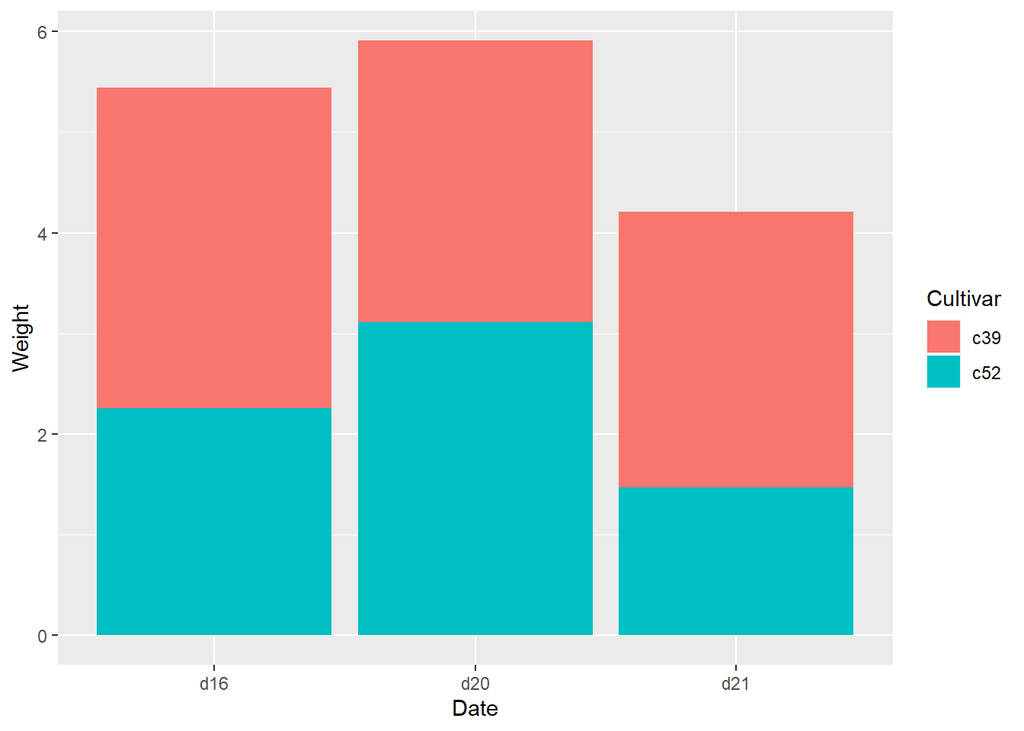

```r
cabbage_exp %>%
  ggplot(aes(x = Date, y = Weight, fill = Cultivar)) +
  geom_bar(stat = "identity")
```

위 stacked bar를 이해하기 위해서는 데이터 구조를 알아야 한다.  
`cabbage_exp`data를 보면 Date는 3Lv - d16, d20, d21 - 로 되어 있고, Cultivar는 2Lv - c39, c52 - 로 되어있다.  
각각의 조합에 따른 Weight가 나열되어 있다.

```r
skimr::skim(cabbage_exp)
```

Data summary

| Name | cabbage_exp |
| --- | --- |
| Number of rows | 6 |
| Number of columns | 6 |
| _______________________ |  |
| Column type frequency: |  |
| factor | 2 |
| numeric | 4 |
| ________________________ |  |
| Group variables | None |

**Variable type: factor**

| skim_variable | n_missing | complete_rate | ordered | n_unique | top_counts |
| --- | --- | --- | --- | --- | --- |
| Cultivar | 0 | 1 | FALSE | 2 | c39: 3, c52: 3 |
| Date | 0 | 1 | FALSE | 3 | d16: 2, d20: 2, d21: 2 |

**Variable type: numeric**

| skim_variable | n_missing | complete_rate | mean | sd | p0 | p25 | p50 | p75 | p100 | hist |
| --- | --- | --- | --- | --- | --- | --- | --- | --- | --- | --- |
| Weight | 0 | 1 | 2.59 | 0.64 | 1.47 | 2.38 | 2.77 | 3.03 | 3.18 | ▃▁▃▇▇ |
| sd | 0 | 1 | 0.61 | 0.34 | 0.21 | 0.32 | 0.62 | 0.92 | 0.98 | ▇▃▁▃▇ |
| n | 0 | 1 | 10.00 | 0.00 | 10.00 | 10.00 | 10.00 | 10.00 | 10.00 | ▁▁▇▁▁ |
| se | 0 | 1 | 0.19 | 0.11 | 0.07 | 0.10 | 0.20 | 0.29 | 0.31 | ▇▃▁▃▇ |

만약 legend의 순서를 바꾸고 싶다면 (c39가 아래, c52가 위로) `guides()`에서 fill 속성을 `guide_legend(reverse = TRUE)`으로 설정하면 된다.

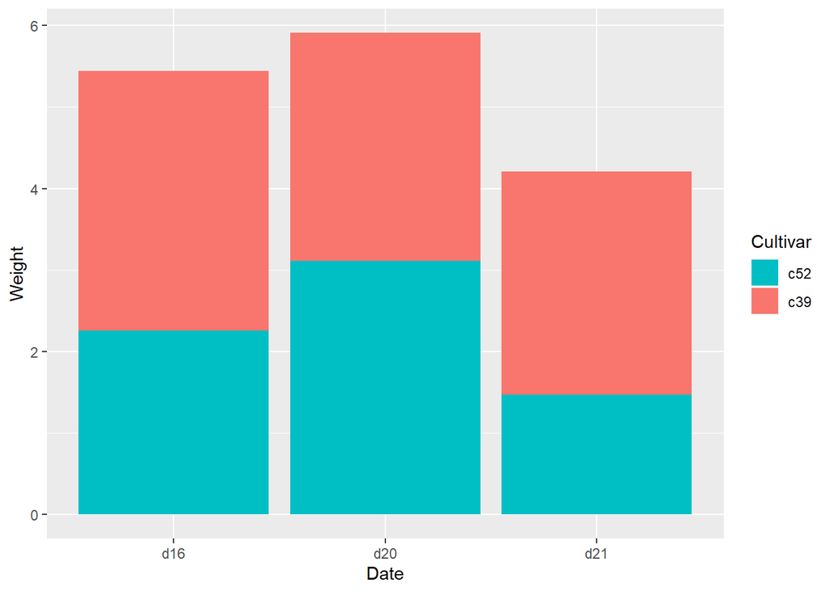

```r
cabbage_exp %>%
  ggplot(aes(x = Date, y = Weight, fill = Cultivar)) +
  geom_bar(stat = "identity") +
  guides(fill = guide_legend(reverse = TRUE))
```

stacking순서를 바꾸고 싶다면 `order = desc()`를 `aes()`에 넣어주면 된다고 책에는 되어 있으나, 이는 ggplot2 ver.2.0.0에서 부터는 사용되지 않는다.  
따라서 stacking 순서를 바꾸고 싶다면 `geom_bar()`에 `position = position_stack(reverse = TRUE)`으로 설정해야 한다.

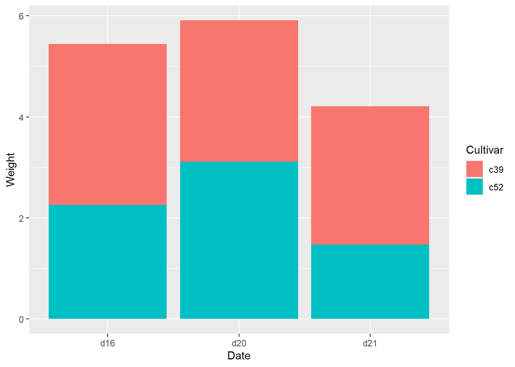

```r
# order = desc() -> NOT WORK ANY MORE
cabbage_exp %>%
  ggplot(aes(x = Date, y = Weight, fill = Cultivar, order = desc(Cultivar))) +
  geom_bar(stat = "identity")
```

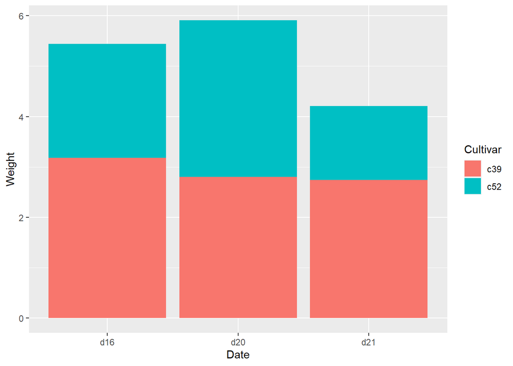

```r
# position = position_stack(reverse = TRUE) -> WORK WELL
cabbage_exp %>%
  ggplot(aes(x = Date, y = Weight, fill = Cultivar)) +
  geom_bar(stat = "identity", position = position_stack(reverse = TRUE))
```

### 3.8 Making a proportional stacked bar graph

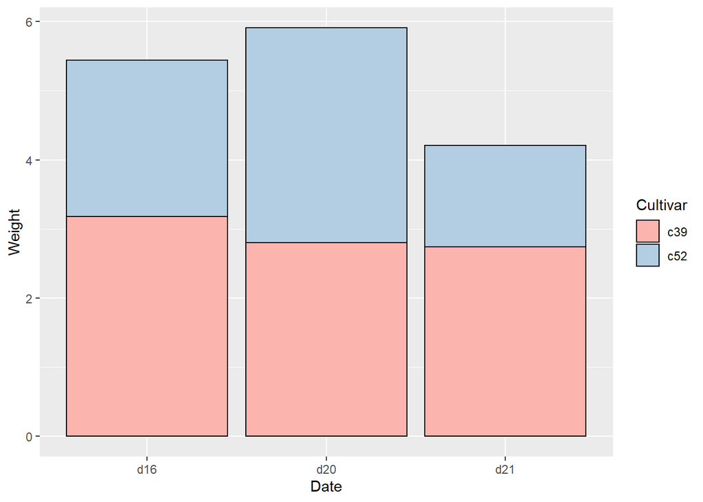

```r
cabbage_exp %>%
  ggplot(aes(x = Date, y = Weight, fill = Cultivar)) +
  geom_bar(stat = "identity", color = "#000000",
           position = position_stack(reverse = TRUE)) +
  scale_fill_brewer(palette = "Pastel1")
```

각 그룹에 포함된 개체들의 비율을 알아야 할 때가 있다.  
예를 들어 d16에 있는 c39와 c51의 비율을 나타내려면 책과 달리 `position = "fill"`을 입력하여 간단하게 구현이 가능하다.

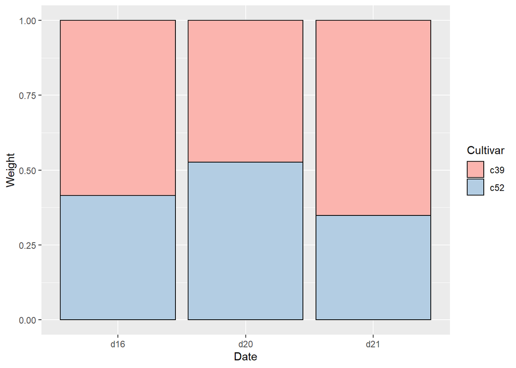

```r
cabbage_exp %>%
  ggplot(aes(x = Date, y = Weight, fill = Cultivar)) +
  geom_bar(stat = "identity", color = "#000000",
           position = "fill") +
  scale_fill_brewer(palette = "Pastel1")
```

앞서 설명한 방법과 동일하게 순서를 바꿔 stacking을 하고 싶으면 `position_fill()`에 reverse = TRUE로 설정하면 된다.

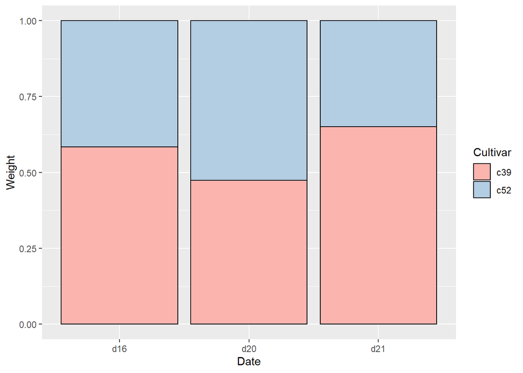

```r
cabbage_exp %>%
  ggplot(aes(x = Date, y = Weight, fill = Cultivar)) +
  geom_bar(stat = "identity", color = "#000000",
           position = position_fill(reverse = TRUE)) +
  scale_fill_brewer(palette = "Pastel1")
```

### 3.9 Adding labels to a bar graph

`interaction()`함수를 사용하여 x축 값을 지정한 bar graph를 그림. vertical justification(vjust)를 이용하여 label값의 위, 아래 위치를 지정할 수 있다.

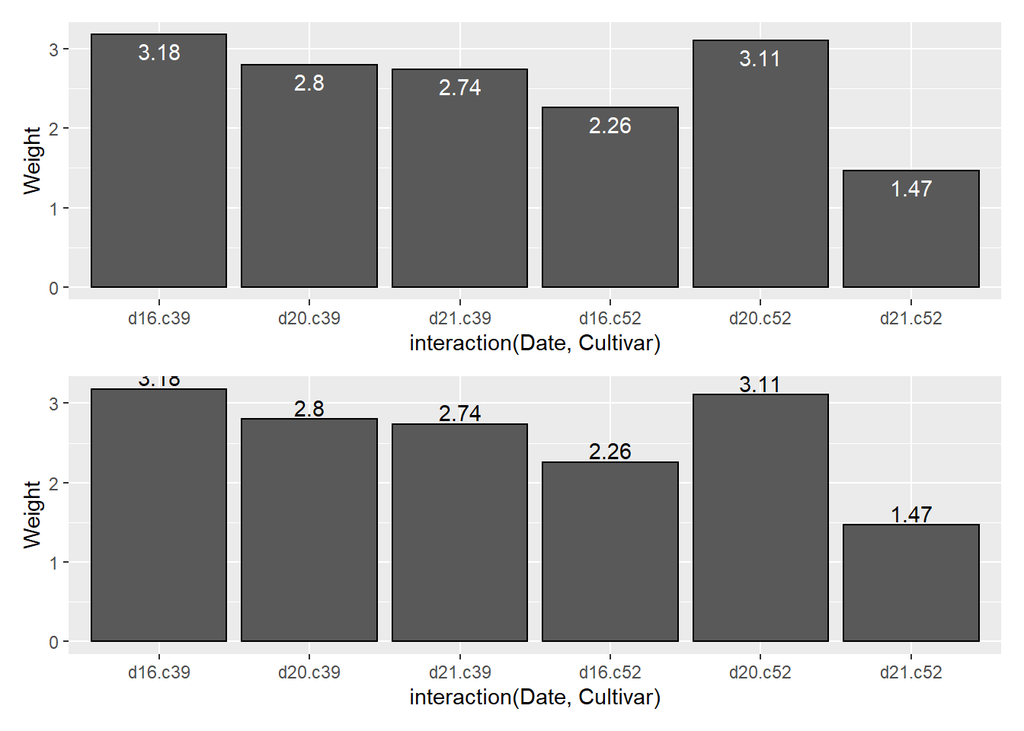

```r
label1 <-
  cabbage_exp %>%
  ggplot(aes(x = interaction(Date, Cultivar), y = Weight, )) +
  geom_bar(stat = "identity", color = "#000000") +
  geom_text(aes(label = Weight), vjust = 1.5, color = "#FFFFFF")

label2 <-
  cabbage_exp %>%
  ggplot(aes(x = interaction(Date, Cultivar), y = Weight, )) +
  geom_bar(stat = "identity", color = "#000000") +
  geom_text(aes(label = Weight), vjust = -0.2, color = "#000000")

label1 / label2
```

때에 따라 위쪽의 label값이 잘려서 나오는 경우가 있다.  
이럴 때는 Y축의 범위(y limit)을 조절하여 나오게 할 수도 있고, label이 출력되는 위치를 바꿀 수도 있다.

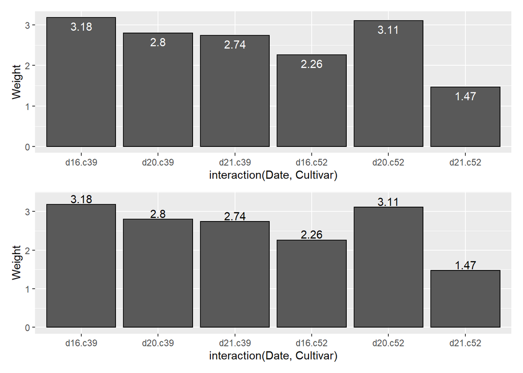

```r
label1 <-
  cabbage_exp %>%
  ggplot(aes(x = interaction(Date, Cultivar), y = Weight, )) +
  geom_bar(stat = "identity", color = "#000000") +
  geom_text(aes(label = Weight), vjust = 1.5, color = "#FFFFFF")

label2 <-
  cabbage_exp %>%
  ggplot(aes(x = interaction(Date, Cultivar), y = Weight, )) +
  geom_bar(stat = "identity", color = "#000000") +
  geom_text(aes(label = Weight), vjust = -0.2, color = "#000000") +
  scale_y_continuous(limits = c(0, max(cabbage_exp$Weight * 1.05)))

label1 / label2
```

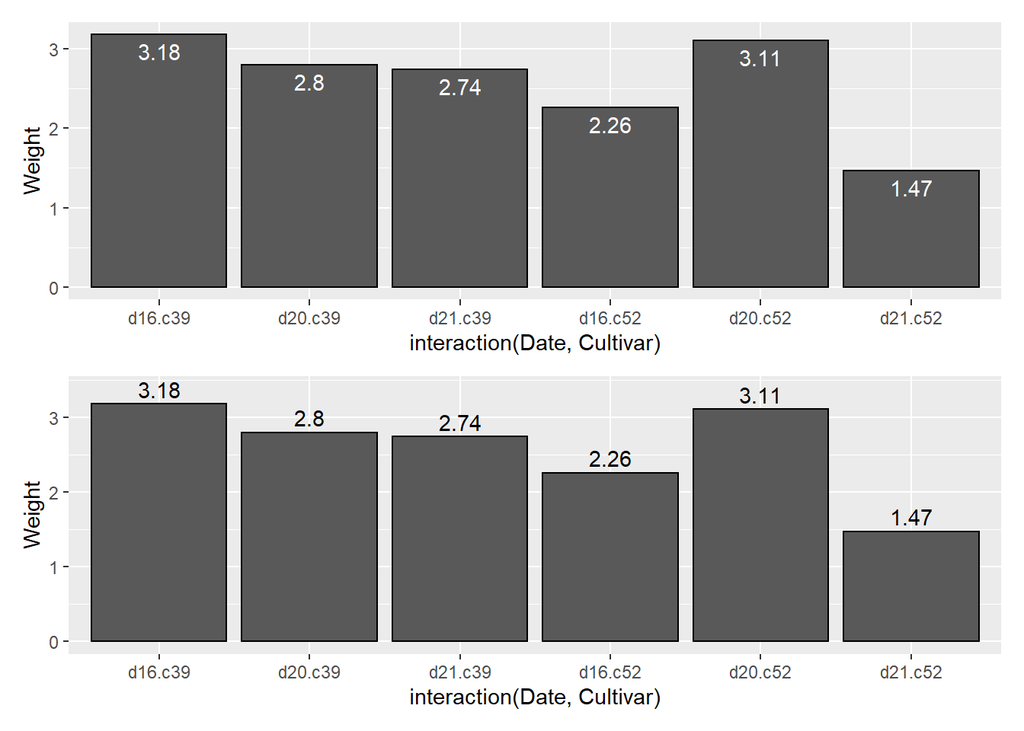

```r
label1 <-
  cabbage_exp %>%
  ggplot(aes(x = interaction(Date, Cultivar), y = Weight, )) +
  geom_bar(stat = "identity", color = "#000000") +
  geom_text(aes(label = Weight), vjust = 1.5, color = "#FFFFFF")

label2 <-
  cabbage_exp %>%
  ggplot(aes(x = interaction(Date, Cultivar), y = Weight, )) +
  geom_bar(stat = "identity", color = "#000000") +
  geom_text(aes(y = Weight + 0.2, label = Weight), color = "#000000")

label1 / label2
```

grouped bar의 경우 dodging width를 정하기 위해서 `position = position_dodge()`를 사용했다. `geom_text()`도 동일하게 `position = position_dodge()`를 적용해야 가운데 몰린 label값이 각 dodge별로 출력된다.  
기본값은 동일하게 0.9이다.  
만약 bar가 좁을 경우는 label값을 `size`를 이용하여 줄여야 한다.  
`size`의 default값은 5이기 때문에 줄이기 위해서는 5보다 작은 값을 입력해줘야 한다.

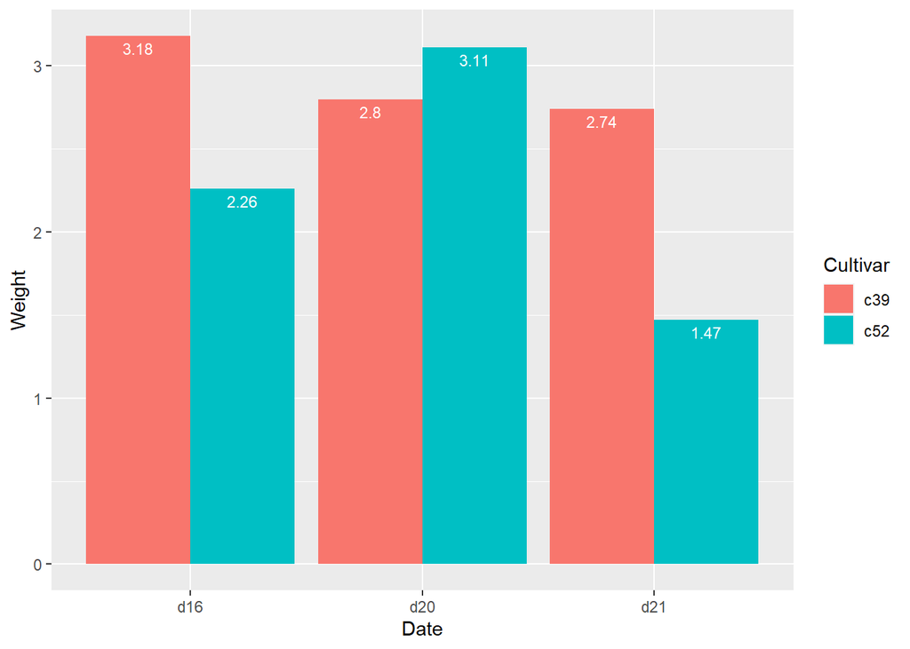

```r
cabbage_exp %>%
  ggplot(aes(x = Date, y = Weight, fill = Cultivar)) +
  geom_bar(stat = "identity", position = "dodge") +
  geom_text(aes(label = Weight), vjust = 1.5, color = "#FFFFFF",
            position = position_dodge(0.9), size = 3)
```

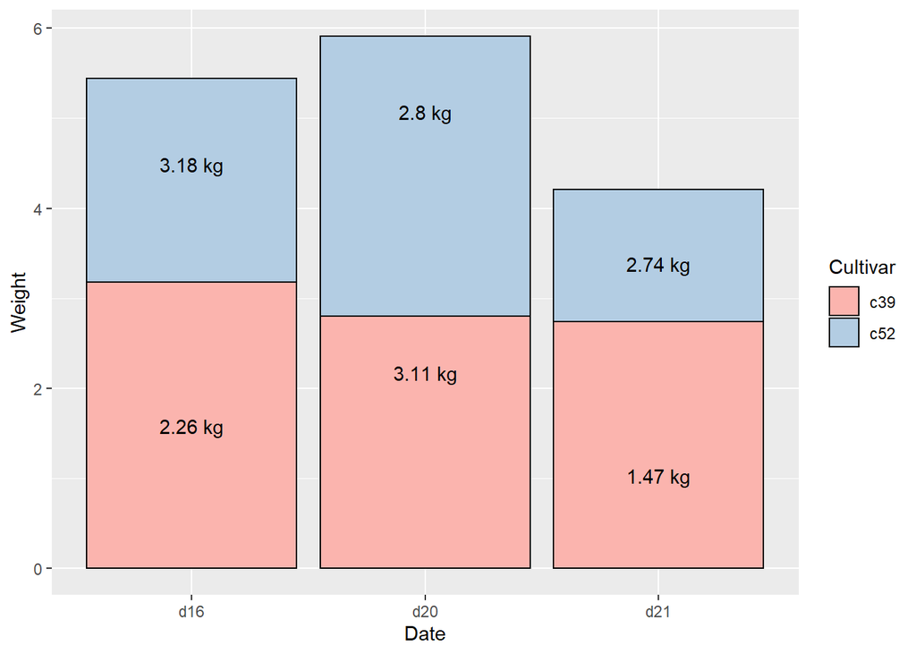

```r
cabbage_exp %>%
  ggplot(aes(x = Date, y = Weight, fill = Cultivar)) +
  geom_bar(stat = "identity", color = "#000000",
           position = position_stack(reverse = TRUE)) +
  geom_text(aes(label = paste(Weight,"kg")),
            position = position_stack(vjust = 0.7)) +
  scale_fill_brewer(palette = "Pastel1")
```

### 3.10 Making a cleveland dot plot

```r
tophitters2001
```

```
##            id    first         last              name year stint team lg   g
## 1   walkela01    Larry       Walker      Larry Walker 2001     1  COL NL 142
## 2   suzukic01   Ichiro       Suzuki     Ichiro Suzuki 2001     1  SEA AL 157
## 3   giambja01    Jason       Giambi      Jason Giambi 2001     1  OAK AL 154
## 4   alomaro01  Roberto       Alomar    Roberto Alomar 2001     1  CLE AL 157
## 5   heltoto01     Todd       Helton       Todd Helton 2001     1  COL NL 159
## 6    aloumo01   Moises         Alou       Moises Alou 2001     1  HOU NL 136
## 7   berkmla01    Lance      Berkman     Lance Berkman 2001     1  HOU NL 156
## 8   boonebr01     Bret        Boone        Bret Boone 2001     1  SEA AL 158
## 9   catalfr01    Frank  Catalanotto Frank Catalanotto 2001     1  TEX AL 133
## 10  jonesch06  Chipper        Jones     Chipper Jones 2001     1  ATL NL 159
## 11  pujolal01   Albert       Pujols     Albert Pujols 2001     1  SLN NL 161
## 12  bondsba01    Barry        Bonds       Barry Bonds 2001     1  SFN NL 153
## 13   sosasa01    Sammy         Sosa        Sammy Sosa 2001     1  CHN NL 160
## 14  pierrju01     Juan       Pierre       Juan Pierre 2001     1  COL NL 156
```

[output cut: 275 more lines]

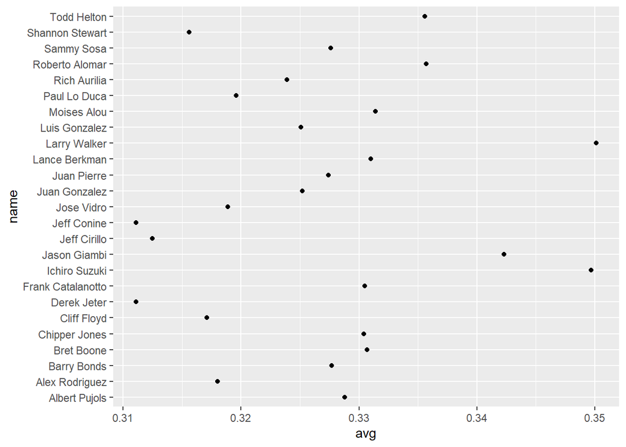

```r
tophit <- tophitters2001[1:25,]

tophit %>%
  ggplot(aes(x = avg, y = name)) +
  geom_point()
```

name은 character vector이므로 알파벳 순서로 plot이 되었음.  
avg 순서로 배치하기 위해서는 name의 factor level을 정해주어야 함.  
그러기 위해서 `reorder()`를 사용하면 name column을 factor로 바꿔주고 avg에 따른 level로 정렬해준다.  
추가적으로 cleveland dot plot의 외형을 가지게 하기 위해 X축의 grid를 없애고 Y축 grid를 적절하게 변경한다.

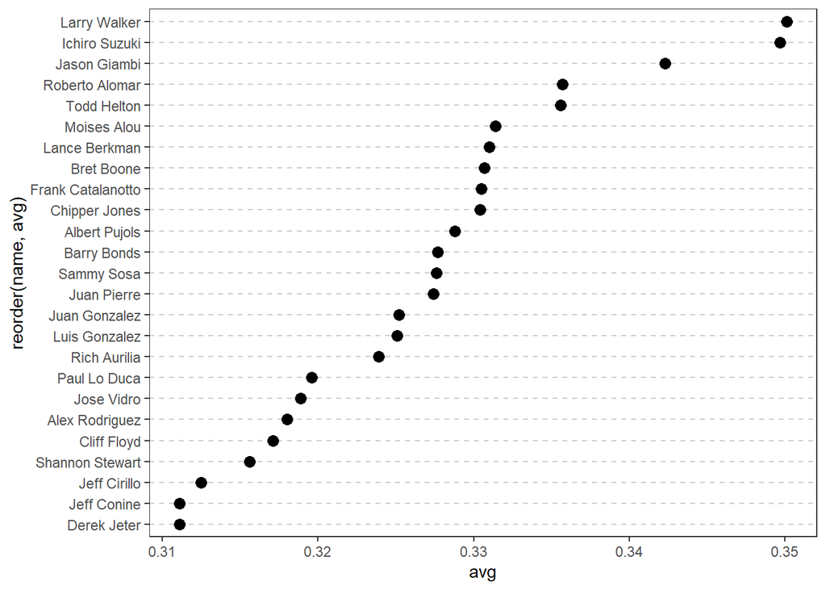

```r
tophit %>%
  ggplot(aes(x = avg, y = reorder(name,avg))) +
  geom_point(size = 3) +
  theme_bw() +
  theme(panel.grid.major.x = element_blank(),
        panel.grid.minor.x = element_blank(),
        panel.grid.major.y = element_line(color = "gray80", linetype = "dashed"))
```

필요에 따라 X-Y축을 바꿀 수도 있다.  
책의 예제와는 다르게 `coord_flip()`를 써서 간단하게 바꾸었다.

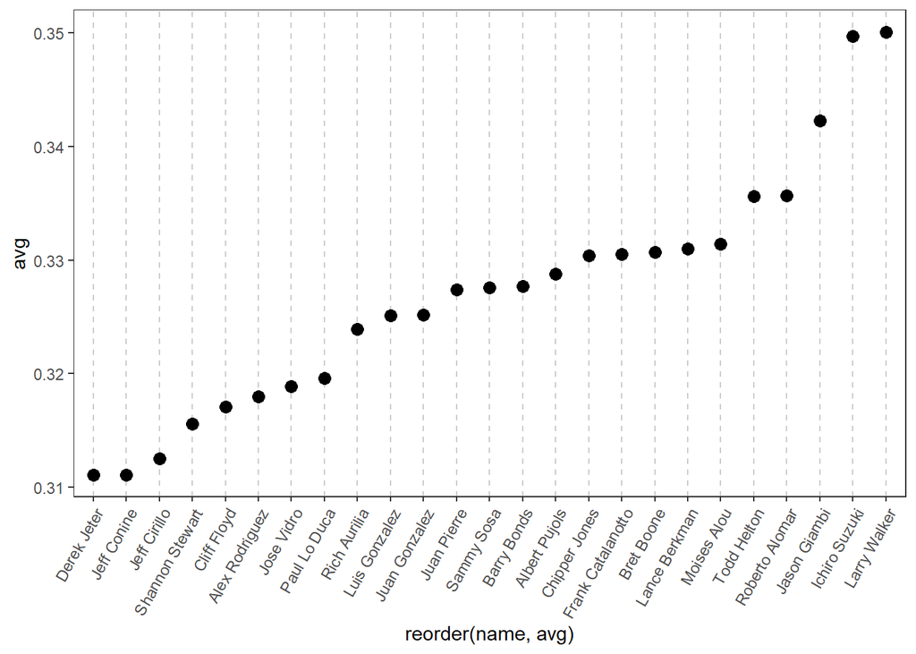

```r
tophit %>%
  ggplot(aes(x = avg, y = reorder(name,avg))) +
  geom_point(size = 3) +
  coord_flip() +
  theme_bw() +
  theme(panel.grid.major.y = element_blank(),
        panel.grid.minor.y = element_blank(),
        panel.grid.major.x = element_line(color = "gray80", linetype = "dashed"),
        axis.text.x = element_text(angle = 60, hjust = 1))
```

lg에 따라 point 색깔을 다르게 하고 점이 있는데까지만 줄이 그어질 수 있게 `geom_segment()`를 사용한다.  
`geom_segment()`를 사용할 때는 x, y, xend, yend를 입력해 주어야 한다.

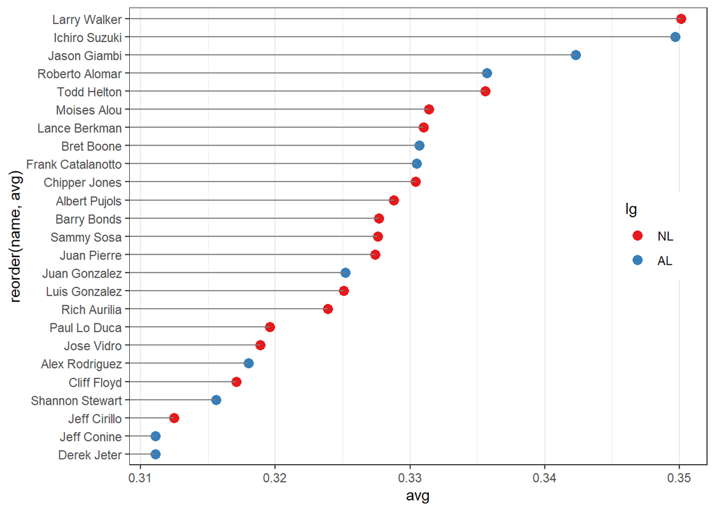

```r
tophit %>%
  ggplot(aes(x = avg, y = reorder(name,avg))) +
  geom_point(aes(color = lg), size = 3) +
  geom_segment(aes(yend = name), xend = 0, color = "gray50") +
  scale_color_brewer(palette = "Set1", limits = c("NL","AL")) +
  theme_bw() +
  theme(panel.grid.major.y = element_blank(),
        legend.position = c(0.9,0.5))
```

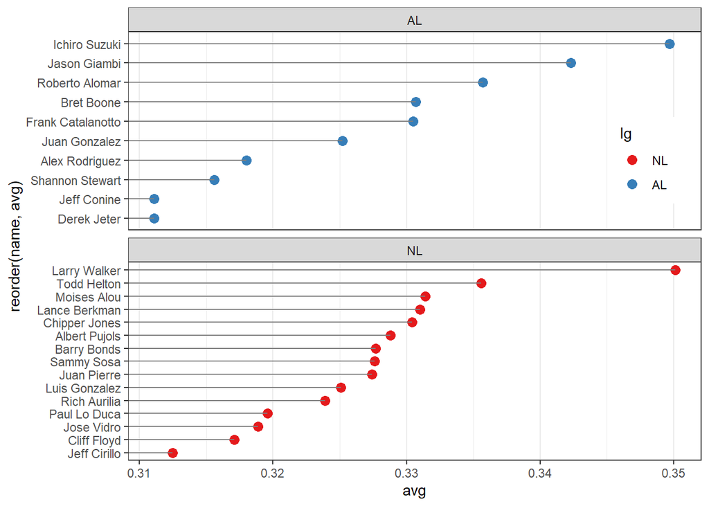

```r
tophit %>%
  ggplot(aes(x = avg, y = reorder(name,avg))) +
  geom_point(aes(color = lg), size = 3) +
  geom_segment(aes(yend = name), xend = 0, color = "gray50") +
  scale_color_brewer(palette = "Set1", limits = c("NL","AL")) +
  theme_bw() +
  theme(panel.grid.major.y = element_blank(),
        legend.position = c(0.9,0.7)) +
  facet_wrap(~ lg, scales = "free_y", ncol = 1)
```

**END**